# 14 Examen final de Introducción a R - Versión B

Bioinformática I — Versión B

Autor/a

Nombre del estudiante

## 14.1 Instrucciones generales

**Duración: 120 minutos. Valor total: 100 puntos.**

El objetivo es reproducir dos figuras a partir de datos reales de mieles de abejas sin aguijón. Los conteos proporcionados corresponden únicamente a bacterias con asignación taxonómica a nivel de filo. Se incluyen 17 muestras de dos especies de abejas.

Trabaja en tu proyecto de RStudio y utiliza este documento como [plantilla](https://github.com/CursosENESJuriquilla/Intro_to_R_Bioinfo_2027-1/raw/refs/heads/main/versionB.qmd) Sustituye el nombre del autor por el tuyo. Agrega tus bloques de código R ejecutables y tus respuestas en las secciones correspondientes. Conserva las rutas relativas y muestra el procedimiento completo. Las figuras de referencia son una guía: no es necesario reproducir exactamente la tipografía ni los tamaños.

## 14.2 Importación y exploración (10 puntos)

Descarga y descomprime datos_B.zip. Importa con `readr` los archivos `datos/conteos_filo_miel_bacterias.tsv` y `datos/metadata_miel_examen.csv`.

- Indica las dimensiones de ambas tablas y el número de muestras por especie de abeja.
- Identifica si existen valores faltantes en los metadatos e indica en qué variable o variables.

## 14.3 Integración y abundancia relativa (20 puntos)

Integra las dos tablas mediante el identificador `sample_id`. Calcula la abundancia relativa de cada filo dentro de cada muestra, dividiendo su conteo entre la suma de los conteos de esa muestra. Conserva las abundancias como proporciones entre 0 y 1.

## 14.4 Figura 1: los 10 filos más abundantes (25 puntos)

Calcula la abundancia relativa promedio de cada filo considerando las 17 muestras, incluidos los conteos cero. Selecciona los diez con mayor promedio y reproduce la gráfica de barras horizontales ordenadas de mayor a menor. Muestra el eje de abundancia en porcentajes y agrega etiquetas apropiadas.

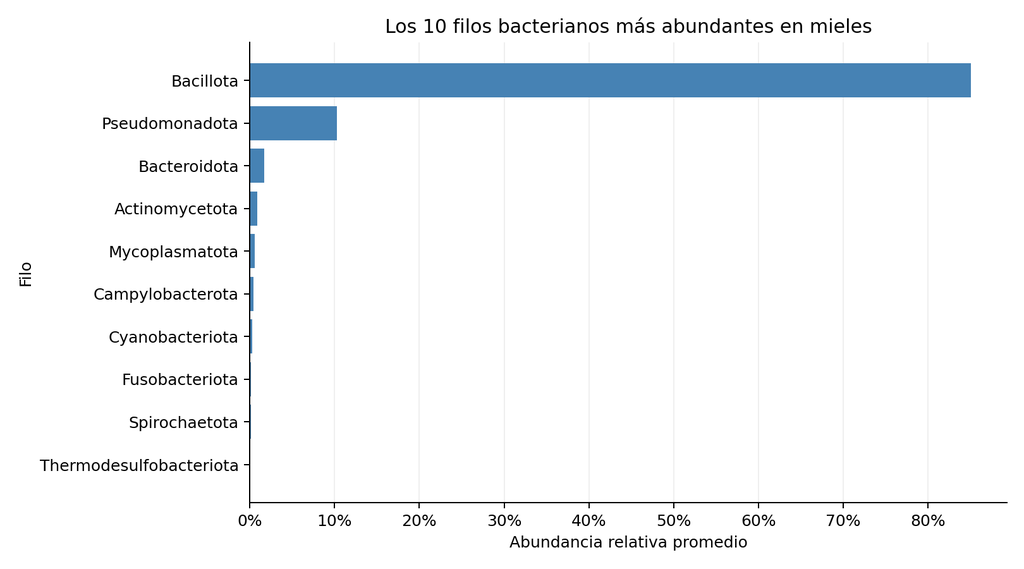

Figura 1. Referencia.

## 14.5 Figura 2: composición bacteriana por muestra (30 puntos)

Utiliza las abundancias relativas del apartado 2, **no solamente los diez taxones de la figura anterior**.

- Dentro de cada muestra, agrupa los filos cuya abundancia relativa sea estrictamente menor al 5 % en la categoría `Filos < 5%`. Suma las abundancias de esa categoría.
- Construye una gráfica de barras apiladas, una barra por muestra, separando las especies de abejas mediante facetas. Cada barra debe sumar 100 %.
- Utiliza la paleta proporcionada y coloca la leyenda debajo de la gráfica.

Paleta de referencia (puedes copiarla en un bloque de R) o puedes usar otra paleta de colores:

```r
phylum_colors_rel <- c(
  "Bacillota" = "#0078A0",
  "Pseudomonadota" = "#499878",
  "Filos < 5%" = "#778899"
)
```

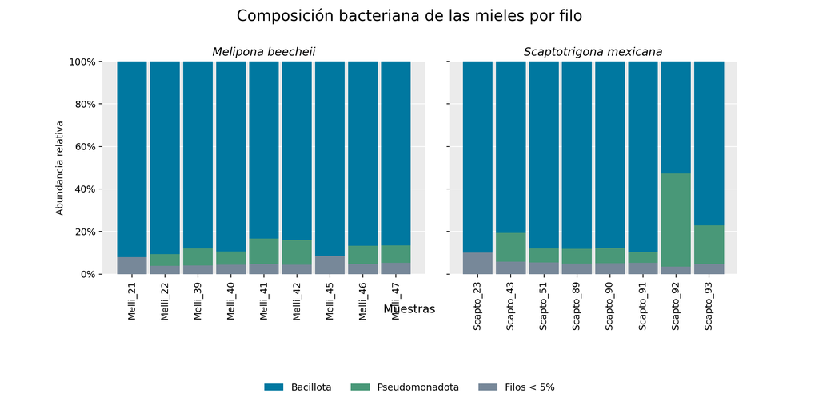

Figura 2. Referencia.

## 14.6 Interpretación (5 puntos)

Responde brevemente con base en tus resultados:

1. ¿Cuál es el filo con mayor abundancia relativa promedio?
2. ¿Qué diferencias o similitudes observas en la composición de las muestras de las dos especies de abejas?

**Nota**: Todas las muestras pertenecen al mismo estudio y fueron procesadas con la misma metodología.

## 14.7 Reporte reproducible y entrega (10 puntos)

Renderiza el documento a HTML y sube a tu repositorio de GitHub el archivo `.qmd`, el HTML generado y las carpetas de datos y figuras necesarias. Verifica que el HTML muestre tus resultados y gráficas sin necesidad de ejecutar el código nuevamente. Entrega el enlace al repositorio.

Si tienes un problema técnico con GitHub, conserva el `.qmd` y el HTML y notifícalo a la profesora antes de finalizar el examen.